```r
dados <- read.delim2("D:/Google Drive/2 - Ufpb/P5/Econometria/Series/Dados/cap3.txt", row.names=1)
dados
```

```
##                DE     FP   TD
## 1995.01  46331.44  78.13  7.9
## 1995.02  46818.79  77.68  8.9
## 1995.03  48113.47  81.66  9.2
## 1995.04  50658.81  83.38  9.4
## 1995.05  53979.63  87.56  9.2
## 1995.06  56569.92  88.76  9.1
## 1995.07  58557.33  89.14  9.1
## 1995.08  59466.12  89.20  8.8
## 1995.09  59253.58  86.66  9.0
## 1995.10  59891.43  90.13  9.0
## 1995.11  60450.73 102.35  9.1
## 1995.12  64266.65 124.97  8.7
## 1996.01  64902.72  96.41  8.5
## 1996.02  65233.10  95.03  9.1
## 1996.03  65267.82  93.05 10.1
## 1996.04  65114.54  91.85 11.0
## 1996.05  64692.97  93.87 10.8
## 1996.06  64510.54  94.97 10.7
## 1996.07  64278.98  97.10 10.3
## 1996.08  64236.00  97.83 10.3
## 1996.09  64726.91  97.61  9.9
## 1996.10  65754.07  97.14  9.7
## 1996.11  67558.05 108.59  9.6
## 1996.12  72652.00 138.35  9.2
## 1997.01  77130.33 101.62  8.9
## 1997.02  78711.82  97.11  9.1
## 1997.03  80034.28  98.39  9.9
## 1997.04  80883.31  98.20 10.7
## 1997.05  81791.65  98.25 10.7
## 1997.06  82927.44  98.67 10.5
## 1997.07  83626.27 100.64 10.2
## 1997.08  85063.78  98.10 10.2
## 1997.09  86591.73  97.79 10.5
## 1997.10  88145.78  97.99 10.5
## 1997.11  93941.90 110.44 10.5
## 1997.12  98211.26 136.19 10.2
## 1998.01 100628.94  99.99 10.3
## 1998.02  98600.98  95.68 11.1
## 1998.03  98108.16  94.76 12.0
```

[output cut: 234 more lines]

```
## 2017.10 698581.33 227.97 14.8
## 2017.11 705588.13 237.94 14.1
## 2017.12 727981.35 263.54 12.9
## 2018.01 725734.25 281.29 13.2
## 2018.02 727848.59 218.67 13.6
## 2018.03 734825.27 281.29 14.5
## 2018.04 738795.11 218.67 14.4
## 2018.05 744039.51 227.97 14.2
## 2018.06 752524.35 229.65 14.1
## 2018.07 759125.38 227.97 14.6
## 2018.08 767980.28 237.94 14.4
## 2018.09 779246.72 263.54 13.9
## 2018.10 779696.01 281.29 13.1
## 2018.11 783382.48 293.53 12.4
## 2018.12 800889.43 296.36 12.5
```

#Modelo Naive

A previsão dele é igual ao valor da última observação ou quando há sazonalidade, a previsão de um mês futuro é igual ao valor da última observação.

```r
summary(naive(dados[,1],h=27))
```

```
##
## Forecast method: Naive method
##
## Model Information:
## Call: naive(y = dados[, 1], h = 27)
##
## Residual sd: 3692.136
##
## Error measures:
##                    ME     RMSE      MAE       MPE     MAPE MASE      ACF1
## Training set 2629.122 4527.323 3137.336 0.9797526 1.165251    1 0.4537878
##
## Forecasts:
##     Point Forecast    Lo 80    Hi 80    Lo 95    Hi 95
## 289       800889.4 795087.4 806691.4 792016.0 809762.8
## 290       800889.4 792684.2 809094.7 788340.6 813438.3
## 291       800889.4 790840.1 810938.8 785520.3 816258.6
## 292       800889.4 789285.4 812493.4 783142.7 818636.2
## 293       800889.4 787915.8 813863.1 781047.9 820730.9
## 294       800889.4 786677.5 815101.4 779154.2 822624.7
## 295       800889.4 785538.8 816240.1 777412.6 824366.2
## 296       800889.4 784478.9 817300.0 775791.7 825987.2
## 297       800889.4 783483.4 818295.4 774269.3 827509.6
## 298       800889.4 782541.9 819237.0 772829.3 828949.6
## 299       800889.4 781646.4 820132.5 771459.7 830319.1
## 300       800889.4 780790.7 820988.1 770151.1 831627.8
## 301       800889.4 779970.0 821808.8 768896.0 832882.9
## 302       800889.4 779180.3 822598.5 767688.2 834090.6
## 303       800889.4 778418.4 823360.5 766522.9 835255.9
## 304       800889.4 777681.4 824097.4 765395.9 836383.0
## 305       800889.4 776967.2 824811.7 764303.5 837475.4
## 306       800889.4 776273.6 825505.2 763242.8 838536.0
## 307       800889.4 775599.1 826179.8 762211.2 839567.6
## 308       800889.4 774942.1 826836.8 761206.4 840572.4
## 309       800889.4 774301.3 827477.5 760226.4 841552.4
## 310       800889.4 773675.6 828103.2 759269.5 842509.3
## 311       800889.4 773064.0 828714.8 758334.1 843444.7
## 312       800889.4 772465.6 829313.3 757418.9 844360.0
## 313       800889.4 771879.4 829899.4 756522.5 845256.4
## 314       800889.4 771304.9 830473.9 755643.8 846135.0
## 315       800889.4 770741.4 831037.5 754781.9 846996.9
```

```r
summary(naive(dados[,2],h=27))
```

```
##
## Forecast method: Naive method
##
## Model Information:
## Call: naive(y = dados[, 2], h = 27)
##
## Residual sd: 32.3072
##
## Error measures:
##                     ME     RMSE      MAE        MPE     MAPE MASE
## Training set 0.7603833 32.25986 19.28512 -0.5905468 10.17468    1
##                    ACF1
## Training set -0.4613094
##
## Forecasts:
##     Point Forecast     Lo 80    Hi 80       Lo 95    Hi 95
## 289         296.36 255.01733 337.7027 233.1318401 359.5882
## 290         296.36 237.89263 354.8274 206.9418787 385.7781
## 291         296.36 224.75239 367.9676 186.8456145 405.8744
## 292         296.36 213.67466 379.0453 169.9036801 422.8163
## 293         296.36 203.91498 388.8050 154.9775363 437.7425
## 294         296.36 195.09155 397.6285 141.4832708 451.2367
## 295         296.36 186.97757 405.7424 129.0740129 463.6460
## 296         296.36 179.42527 413.2947 117.5237574 475.1962
## 297         296.36 172.33199 420.3880 106.6755202 486.0445
## 298         296.36 165.62299 427.0970  96.4150023 496.3050
## 299         296.36 159.24187 433.4781  86.6559173 506.0641
## 300         296.36 153.14478 439.5752  77.3312290 515.3888
## 301         296.36 147.29688 445.4231  68.3876273 524.3324
## 302         296.36 141.66989 451.0501  59.7818883 532.9381
## 303         296.36 136.24052 456.4795  51.4783895 541.2416
## 304         296.36 130.98931 461.7307  43.4473602 549.2726
## 305         296.36 125.89980 466.8202  35.6636180 557.0564
## 306         296.36 120.95790 471.7621  28.1056360 564.6144
## 307         296.36 116.15147 476.5685  20.7548404 571.9652
## 308         296.36 111.46995 481.2500  13.5950725 579.1249
## 309         296.36 106.90408 485.8159   6.6121710 586.1078
## 310         296.36 102.44568 490.2743  -0.2063579 592.9264
## 311         296.36  98.08751 494.6325  -6.8716026 599.5916
## 312         296.36  93.82310 498.8969 -13.3934585 606.1135
## 313         296.36  89.64664 503.0734 -19.7807997 612.5008
## 314         296.36  85.55291 507.1671 -26.0416214 618.7616
## 315         296.36  81.53718 511.1828 -32.1831565 624.9032
```

```r
summary(naive(dados[,3],h=27))
```

```
##
## Forecast method: Naive method
##
## Model Information:
## Call: naive(y = dados[, 3], h = 27)
##
## Residual sd: 0.4592
##
## Error measures:
##                      ME      RMSE       MAE        MPE     MAPE MASE
## Training set 0.01602787 0.4586756 0.3679443 0.06203769 3.494064    1
##                   ACF1
## Training set 0.4678393
##
## Forecasts:
##     Point Forecast     Lo 80    Hi 80     Lo 95    Hi 95
## 289           12.5 11.912184 13.08782 11.601012 13.39899
## 290           12.5 11.668702 13.33130 11.228640 13.77136
## 291           12.5 11.481872 13.51813 10.942908 14.05709
## 292           12.5 11.324367 13.67563 10.702025 14.29798
## 293           12.5 11.185603 13.81440 10.489803 14.51020
## 294           12.5 11.060150 13.93985 10.297939 14.70206
## 295           12.5 10.944784 14.05522 10.121502 14.87850
## 296           12.5 10.837404 14.16260  9.957279 15.04272
## 297           12.5 10.736551 14.26345  9.803037 15.19696
## 298           12.5 10.641161 14.35884  9.657152 15.34285
## 299           12.5 10.550434 14.44957  9.518395 15.48160
## 300           12.5 10.463744 14.53626  9.385816 15.61418
## 301           12.5 10.380598 14.61940  9.258654 15.74135
## 302           12.5 10.300592 14.69941  9.136296 15.86370
## 303           12.5 10.223397 14.77660  9.018236 15.98176
## 304           12.5 10.148734 14.85127  8.904050 16.09595
## 305           12.5 10.076371 14.92363  8.793379 16.20662
## 306           12.5 10.006106 14.99389  8.685919 16.31408
## 307           12.5  9.937768 15.06223  8.581404 16.41860
## 308           12.5  9.871205 15.12879  8.479605 16.52039
## 309           12.5  9.806287 15.19371  8.380321 16.61968
## 310           12.5  9.742897 15.25710  8.283374 16.71663
## 311           12.5  9.680932 15.31907  8.188607 16.81139
## 312           12.5  9.620300 15.37970  8.095878 16.90412
## 313           12.5  9.560918 15.43908  8.005062 16.99494
## 314           12.5  9.502713 15.49729  7.916045 17.08396
## 315           12.5  9.445616 15.55438  7.828723 17.17128
```

#Gráfico Naive

Mostra que a previsão para qualquer tempo futuro é igual ao último valor observado e o intervalo de confiança vai aumentando com o tempo.

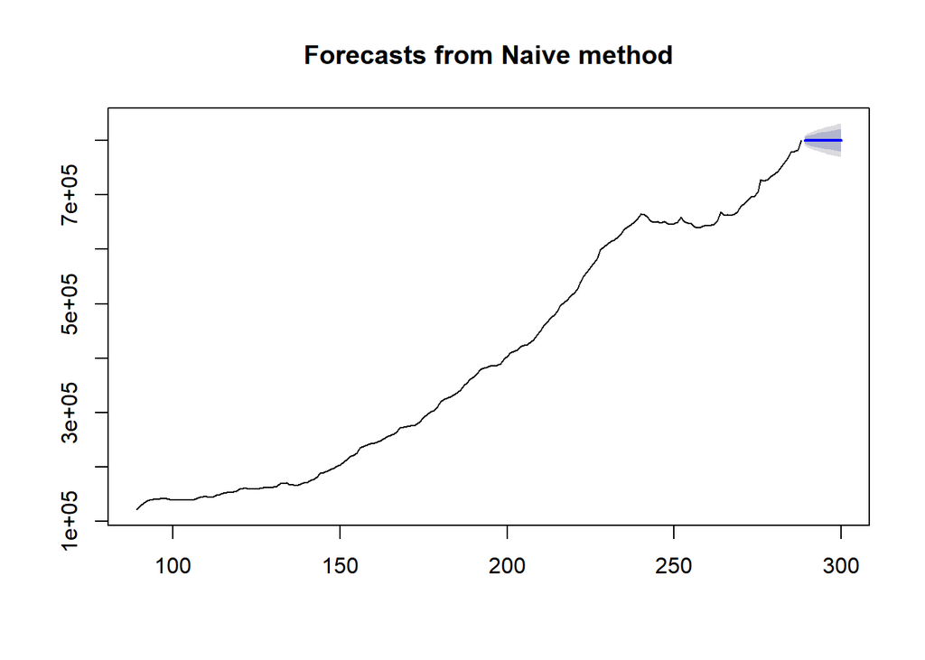

```r
plot(naive(dados[,1],h=12),include = 200)
```

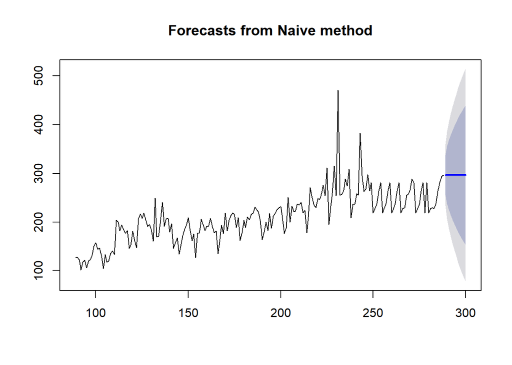

```r
plot(naive(dados[,2],h=12),include = 200)
```

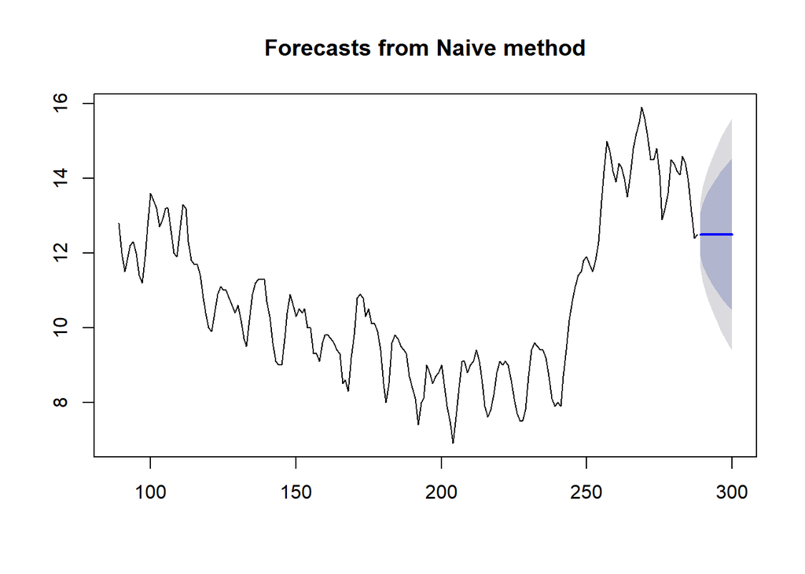

```r
plot(naive(dados[,3],h=12),include = 200)
```

#Modelo Snaive

```r
summary(snaive(dados[,1],h=12))
```

```
##
## Forecast method: Seasonal naive method
##
## Model Information:
## Call: snaive(y = dados[, 1], h = 12)
##
## Residual sd: 3692.136
##
## Error measures:
##                    ME     RMSE      MAE       MPE     MAPE MASE      ACF1
## Training set 2629.122 4527.323 3137.336 0.9797526 1.165251    1 0.4537878
##
## Forecasts:
##     Point Forecast    Lo 80    Hi 80    Lo 95    Hi 95
## 289       800889.4 795087.4 806691.4 792016.0 809762.8
## 290       800889.4 792684.2 809094.7 788340.6 813438.3
## 291       800889.4 790840.1 810938.8 785520.3 816258.6
## 292       800889.4 789285.4 812493.4 783142.7 818636.2
## 293       800889.4 787915.8 813863.1 781047.9 820730.9
## 294       800889.4 786677.5 815101.4 779154.2 822624.7
## 295       800889.4 785538.8 816240.1 777412.6 824366.2
## 296       800889.4 784478.9 817300.0 775791.7 825987.2
## 297       800889.4 783483.4 818295.4 774269.3 827509.6
## 298       800889.4 782541.9 819237.0 772829.3 828949.6
## 299       800889.4 781646.4 820132.5 771459.7 830319.1
## 300       800889.4 780790.7 820988.1 770151.1 831627.8
```

```r
summary(snaive(dados[,2],h=12))
```

```
##
## Forecast method: Seasonal naive method
##
## Model Information:
## Call: snaive(y = dados[, 2], h = 12)
##
## Residual sd: 32.3072
##
## Error measures:
##                     ME     RMSE      MAE        MPE     MAPE MASE
## Training set 0.7603833 32.25986 19.28512 -0.5905468 10.17468    1
##                    ACF1
## Training set -0.4613094
##
## Forecasts:
##     Point Forecast    Lo 80    Hi 80     Lo 95    Hi 95
## 289         296.36 255.0173 337.7027 233.13184 359.5882
## 290         296.36 237.8926 354.8274 206.94188 385.7781
## 291         296.36 224.7524 367.9676 186.84561 405.8744
## 292         296.36 213.6747 379.0453 169.90368 422.8163
## 293         296.36 203.9150 388.8050 154.97754 437.7425
## 294         296.36 195.0915 397.6285 141.48327 451.2367
## 295         296.36 186.9776 405.7424 129.07401 463.6460
## 296         296.36 179.4253 413.2947 117.52376 475.1962
## 297         296.36 172.3320 420.3880 106.67552 486.0445
## 298         296.36 165.6230 427.0970  96.41500 496.3050
## 299         296.36 159.2419 433.4781  86.65592 506.0641
## 300         296.36 153.1448 439.5752  77.33123 515.3888
```

```r
summary(snaive(dados[,3],h=12))
```

```
##
## Forecast method: Seasonal naive method
##
## Model Information:
## Call: snaive(y = dados[, 3], h = 12)
##
## Residual sd: 0.4592
##
## Error measures:
##                      ME      RMSE       MAE        MPE     MAPE MASE
## Training set 0.01602787 0.4586756 0.3679443 0.06203769 3.494064    1
##                   ACF1
## Training set 0.4678393
##
## Forecasts:
##     Point Forecast    Lo 80    Hi 80     Lo 95    Hi 95
## 289           12.5 11.91218 13.08782 11.601012 13.39899
## 290           12.5 11.66870 13.33130 11.228640 13.77136
## 291           12.5 11.48187 13.51813 10.942908 14.05709
## 292           12.5 11.32437 13.67563 10.702025 14.29798
## 293           12.5 11.18560 13.81440 10.489803 14.51020
## 294           12.5 11.06015 13.93985 10.297939 14.70206
## 295           12.5 10.94478 14.05522 10.121502 14.87850
## 296           12.5 10.83740 14.16260  9.957279 15.04272
## 297           12.5 10.73655 14.26345  9.803037 15.19696
## 298           12.5 10.64116 14.35884  9.657152 15.34285
## 299           12.5 10.55043 14.44957  9.518395 15.48160
## 300           12.5 10.46374 14.53626  9.385816 15.61418
```

#Gráfico Snaive

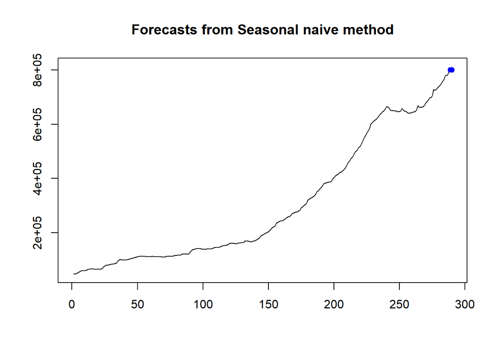

```r
plot(snaive(dados[,1]))
```

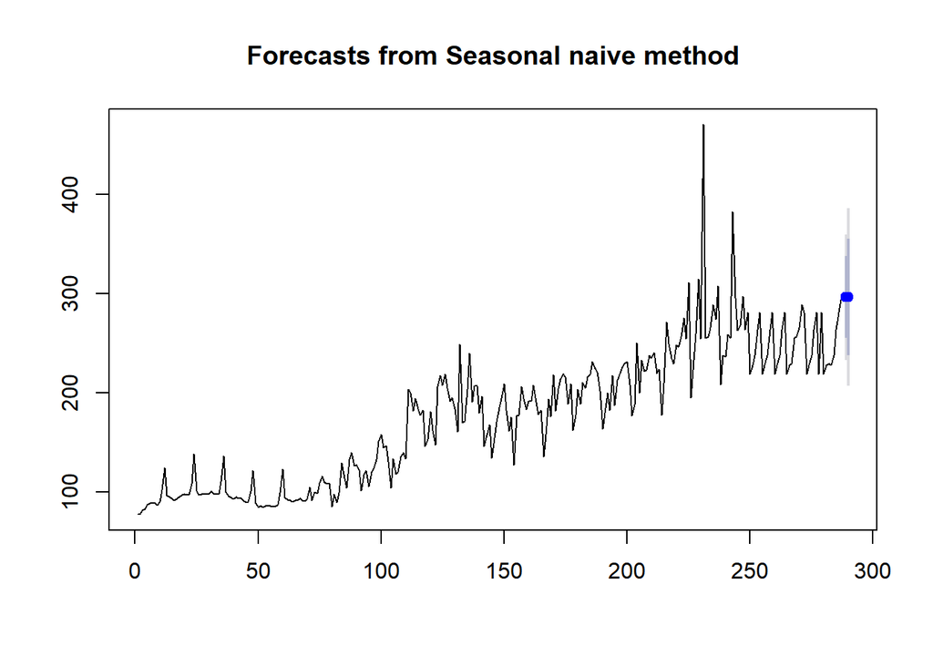

```r
plot(snaive(dados[,2]))
```

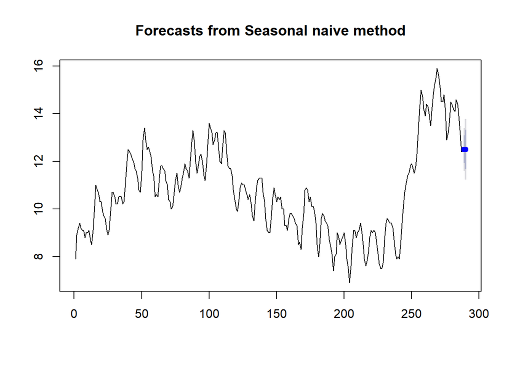

```r
plot(snaive(dados[,3]))
```

#Média móvel centrada

Média móvel é uma média que se movimenta, ou seja, todas as médias móveis têm como padrão um intervalo de período fixo (“janela”) onde para cada nova informação que entrar, retira-se a mais antiga e recalcula-se a média.

```r
mm_centrada_DE6 <- ma(dados[,1],order=6)
mm_centrada_FP6 <- ma(dados[,2],order=6)
mm_centrada_TD6 <- ma(dados[,3],order=6)
```

```r
mm_centrada_DE12 <- ma(dados[,1],order=12)
mm_centrada_FP12 <- ma(dados[,2],order=12)
mm_centrada_TD12 <- ma(dados[,3],order=12)
```

```r
summary(mm_centrada_DE6)
```

```
##    Min. 1st Qu.  Median    Mean 3rd Qu.    Max.    NA's
##   51431  112595  186840  300463  485664  774356       6
```

```r
summary(mm_centrada_FP6)
```

```
##    Min. 1st Qu.  Median    Mean 3rd Qu.    Max.    NA's
##   83.78  106.12  185.44  176.31  229.38  302.36       6
```

```r
summary(mm_centrada_TD6)
```

```
##    Min. 1st Qu.  Median    Mean 3rd Qu.    Max.    NA's
##   7.850   9.213  10.471  10.739  11.923  15.325       6
```

```r
summary(mm_centrada_DE12)
```

```
##    Min. 1st Qu.  Median    Mean 3rd Qu.    Max.    NA's
##   56137  113269  186540  298159  474216  754803      12
```

```r
summary(mm_centrada_FP12)
```

```
##    Min. 1st Qu.  Median    Mean 3rd Qu.    Max.    NA's
##   90.43  102.85  183.85  176.54  229.42  282.59      12
```

```r
summary(mm_centrada_TD12)
```

```
##    Min. 1st Qu.  Median    Mean 3rd Qu.    Max.    NA's
##   8.287   9.366  10.506  10.722  11.950  14.796      12
```

É possível notar que quanto maior é a “janela”, mais suavizado ficar a série, e quanto menor é a “janela”, mais próximo da série original fica o ajuste.

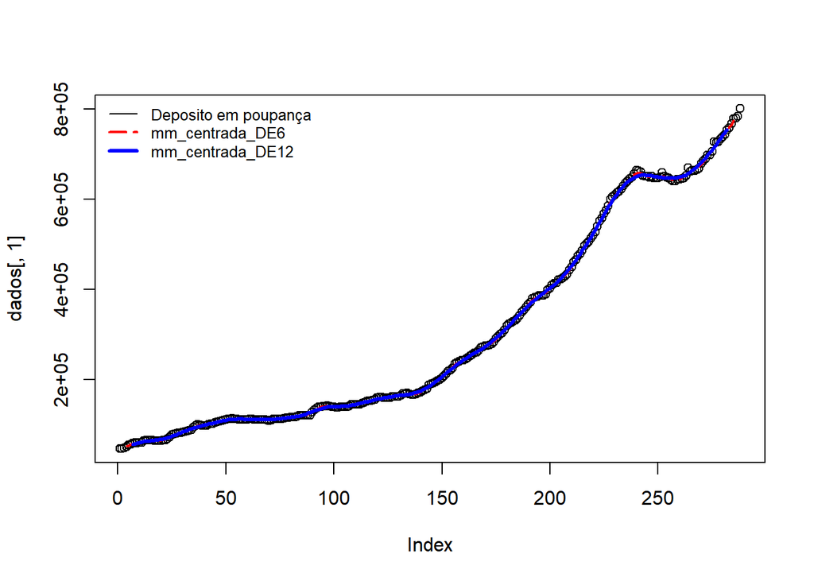

```r
plot(dados[,1])
lines(mm_centrada_DE6,col="red",lty=5,lwd =2)
lines(mm_centrada_DE12,col="blue",lty=1 , lwd =3)
legend('topleft', legend=c("Deposito em poupança", "mm_centrada_DE6","mm_centrada_DE12"),
bty = "n",col=c("black","red", "blue"), lty=c(1,5,1), cex=0.8,lwd =c(1,2,3))
```

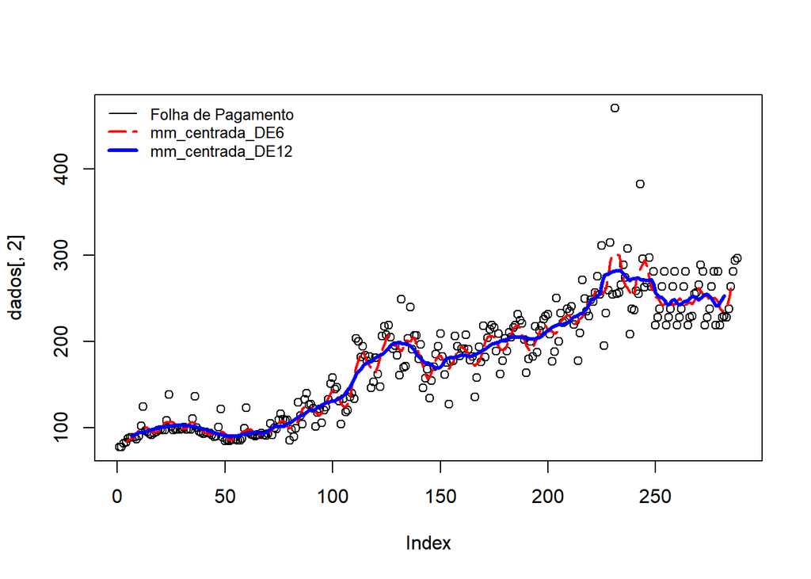

```r
plot(dados[,2])
lines(mm_centrada_FP6,col="red",lty=5,lwd =2)
lines(mm_centrada_FP12,col="blue",lty=1 , lwd =3)
legend('topleft', legend=c("Folha de Pagamento", "mm_centrada_DE6","mm_centrada_DE12"),
bty = "n",col=c("black","red", "blue"), lty=c(1,5,1), cex=0.8,lwd =c(1,2,3))
```

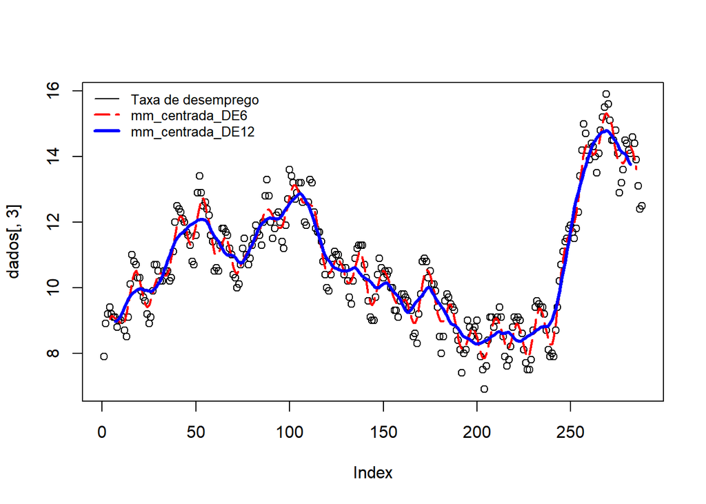

```r
plot(dados[,3])
lines(mm_centrada_TD6,col="red",lty=5,lwd =2)
lines(mm_centrada_TD12,col="blue",lty=1 , lwd =3)
legend('topleft', legend=c("Taxa de desemprego", "mm_centrada_DE6","mm_centrada_DE12"),
bty = "n",col=c("black","red", "blue"), lty=c(1,5,1), cex=0.8,lwd =c(1,2,3))
```

Série suavizada sem influênica da sazonalidade, foi utilizada uma “janela” de tamanho 12.

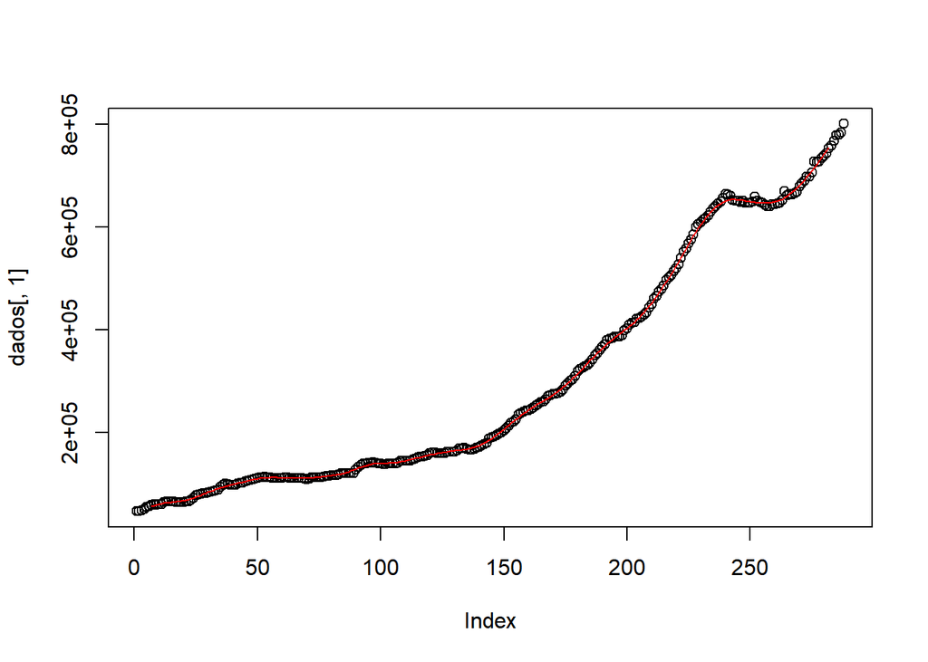

```r
plot(dados[,1])
mm_centrada_DE12 <- ma(dados[,1],order=12)
lines(mm_centrada_DE12,col="red")
```

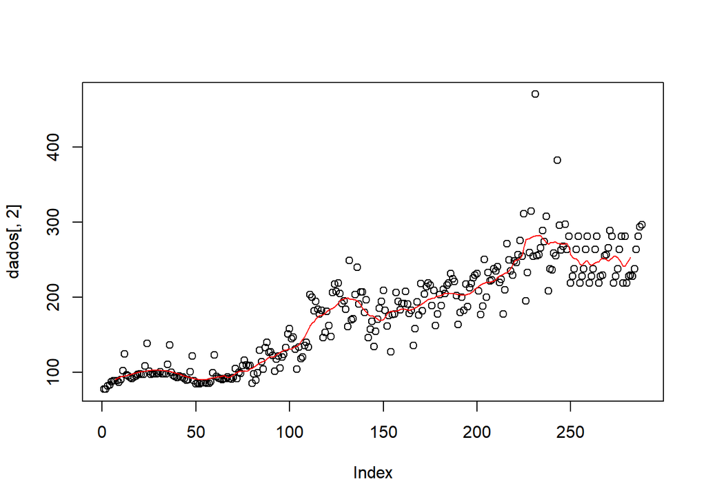

```r
plot(dados[,2])
mm_centrada_FP12 <- ma(dados[,2],order=12)
lines(mm_centrada_FP12,col="red")
```

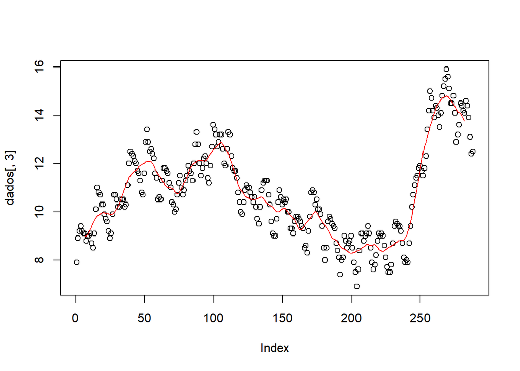

```r
plot(dados[,3])
mm_centrada_TD12 <- ma(dados[,3],order=12)
lines(mm_centrada_TD12,col="red")
```

#Média Móvel Simples # z = Série temporal # r = Tamanho # l = Número

```r
zDE <- dados[,1]
lDE <- 15
rDE <- 288
IC_DE <- function(zDE,rDE,lDE){
smadfDE <- SMA(zDE,rDE)
IC_IDE <- rep(smadfDE[length(zDE)],lDE) - 1.96*sd(zDE)/sqrt(rDE)
IC_SDE <- rep(smadfDE[length(zDE)],lDE) + 1.96*sd(zDE)/sqrt(rDE)
previsaoDE <- rep(smadf[length(zDE)],lDE)
cbind(IC_IDE,previsaoDE,IC_SDE)
}


zFP <- dados[,2]
lFP <- 15
r <- 288
IC_FP <- function(zFP,rFP,lFP){
smadfFP <- SMA(zFP,rFP)
IC_IFP <- rep(smadfFP[length(zFP)],l) - 1.96*sd(zFP)/sqrt(rFP)
IC_SFP <- rep(smadfFP[length(zFP)],l) + 1.96*sd(zFP)/sqrt(rFP)
previsaoFP <- rep(smadfFP[length(zFP)],lFP)
cbind(IC_IFP,previsaoFP,IC_SFP)
}

zTD <- dados[,3]
lTD <- 15
rTD <- 288
IC_TD <- function(zTD,rTD,lTD){
smadfTD <- SMA(zTD,rTD)
IC_ITD <- rep(smadfTD[length(zTD)],lTD) - 1.96*sd(zTD)/sqrt(rTD)
IC_STD <- rep(smadfTD[length(zTD)],lTD) + 1.96*sd(zTD)/sqrt(rTD)
previsaoTD <- rep(smadfTD[length(zTD)],lTD)
cbind(IC_ITD,previsaoTD,IC_STD)
}
```

#Modelos de suavização exponencial #Modelos para séries localmente constantes #Suavização exponencial simples(SES)

A previsão desse modelo é igual ao último valor exponencial suavizado obtido.

```r
serieDE = ts(dados[,1],start = c(1991,1),frequency = 1)
serieFP = ts(dados[,2],start = c(2000,1),frequency = 1)
serieTD = ts(dados[,3],start = c(1991,1),frequency = 1)
```

```r
ajusteDE<-HoltWinters((serieDE), beta=FALSE, gamma=FALSE)
ajusteDE
```

```
## Holt-Winters exponential smoothing without trend and without seasonal component.
##
## Call:
## HoltWinters(x = (serieDE), beta = FALSE, gamma = FALSE)
##
## Smoothing parameters:
##  alpha: 0.9999497
##  beta : FALSE
##  gamma: FALSE
##
## Coefficients:
##       [,1]
## a 800888.5
```

```r
ajusteFP<-HoltWinters((serieFP), beta=FALSE, gamma=FALSE)
ajusteFP
```

```
## Holt-Winters exponential smoothing without trend and without seasonal component.
##
## Call:
## HoltWinters(x = (serieFP), beta = FALSE, gamma = FALSE)
##
## Smoothing parameters:
##  alpha: 0.2263615
##  beta : FALSE
##  gamma: FALSE
##
## Coefficients:
##       [,1]
## a 269.2593
```

```r
ajusteTD<-HoltWinters((serieTD), beta=FALSE, gamma=FALSE)
ajusteTD
```

```
## Holt-Winters exponential smoothing without trend and without seasonal component.
##
## Call:
## HoltWinters(x = (serieTD), beta = FALSE, gamma = FALSE)
##
## Smoothing parameters:
##  alpha: 0.9999339
##  beta : FALSE
##  gamma: FALSE
##
## Coefficients:
##       [,1]
## a 12.49999
```

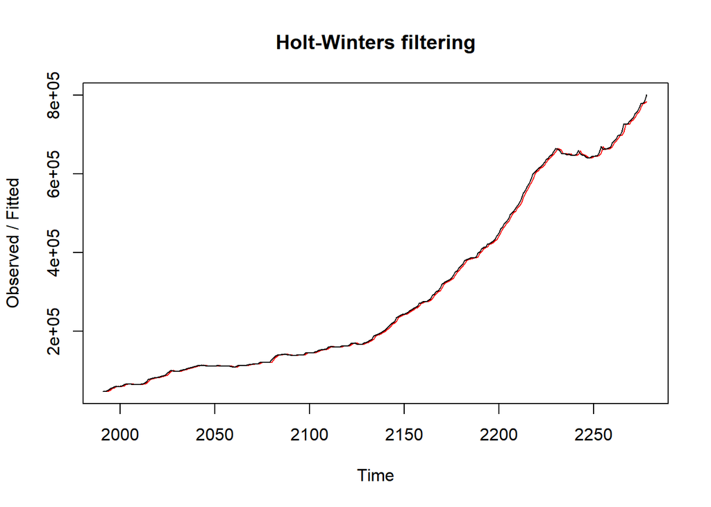

```r
plot(ajusteDE)
```

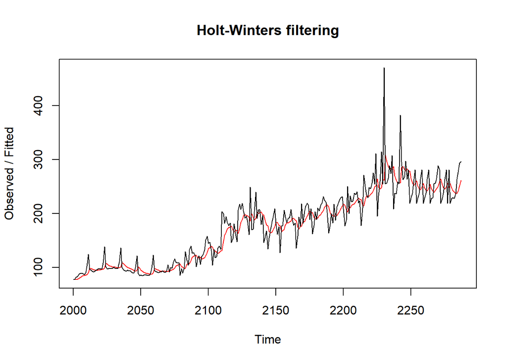

```r
plot(ajusteFP)
```

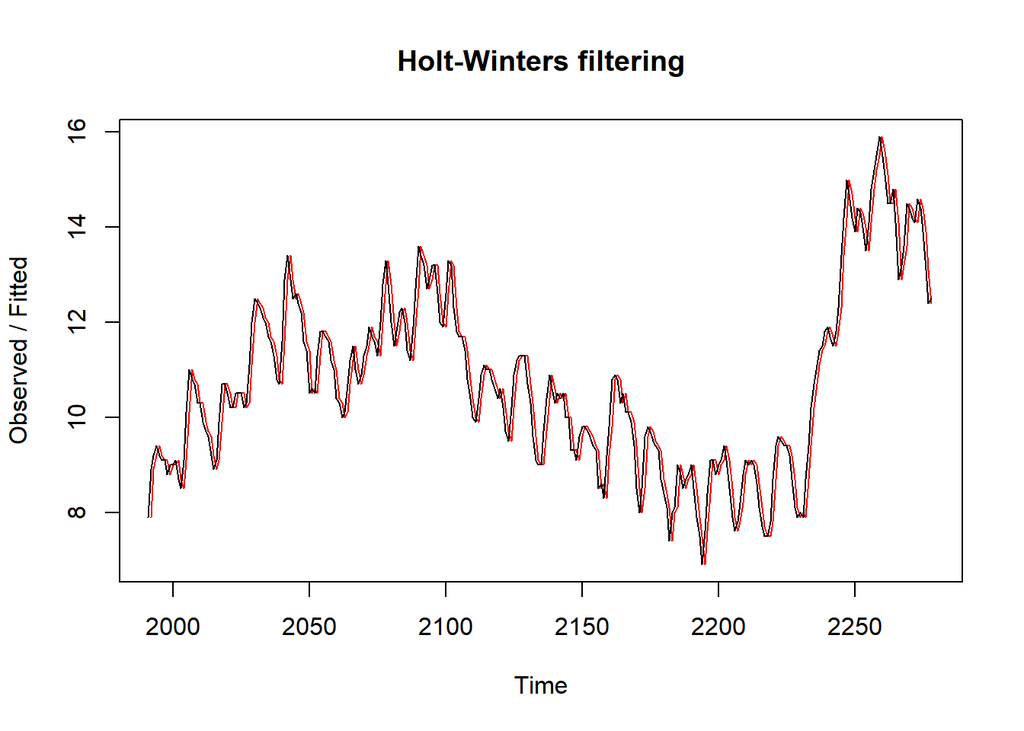

```r
plot(ajusteTD)
```

#Modelo para séries com tendência Suavização exponencial de Holt (SEH)

```r
ajuste_com_tendenciaDE<-HoltWinters(dados[,1], gamma=FALSE)
ajuste_com_tendenciaDE
```

```
## Holt-Winters exponential smoothing with trend and without seasonal component.
##
## Call:
## HoltWinters(x = dados[, 1], gamma = FALSE)
##
## Smoothing parameters:
##  alpha: 1
##  beta : 0.203323
##  gamma: FALSE
##
## Coefficients:
##         [,1]
## a 800889.430
## b   8053.882
```

```r
ajuste_com_tendenciaFP<-HoltWinters(dados[,2], gamma=FALSE)
ajuste_com_tendenciaFP
```

```
## Holt-Winters exponential smoothing with trend and without seasonal component.
##
## Call:
## HoltWinters(x = dados[, 2], gamma = FALSE)
##
## Smoothing parameters:
##  alpha: 0.2155786
##  beta : 0.009025177
##  gamma: FALSE
##
## Coefficients:
##          [,1]
## a 269.6699512
## b   0.5435858
```

```r
ajuste_com_tendenciaTD<-HoltWinters(dados[,3], gamma=FALSE)
ajuste_com_tendenciaTD
```

```
## Holt-Winters exponential smoothing with trend and without seasonal component.
##
## Call:
## HoltWinters(x = dados[, 3], gamma = FALSE)
##
## Smoothing parameters:
##  alpha: 1
##  beta : 0.8882952
##  gamma: FALSE
##
## Coefficients:
##           [,1]
## a 12.500000000
## b  0.009864207
```

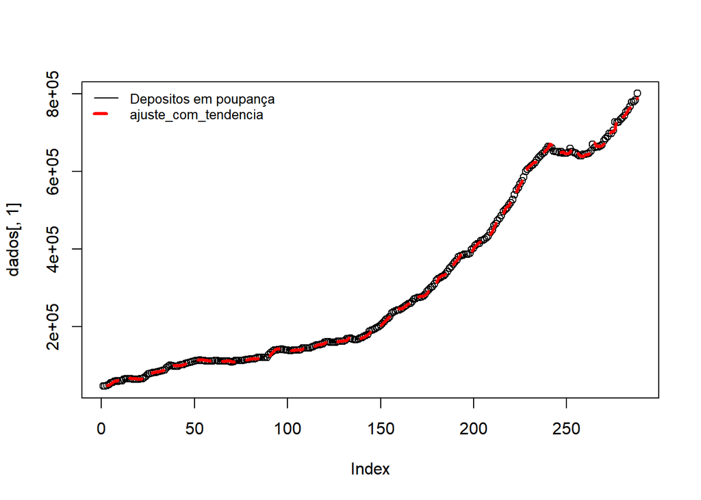

```r
plot(dados[,1])
lines(fitted(ajuste_com_tendenciaDE)[,1],col="red",lty=2,lwd =3)
legend('topleft', legend=c("Depositos em poupança", "ajuste_com_tendencia"),bty = "n",
       col=c("black","red"), lty=c(1,2), cex=0.8,lwd =c(1,3))
```

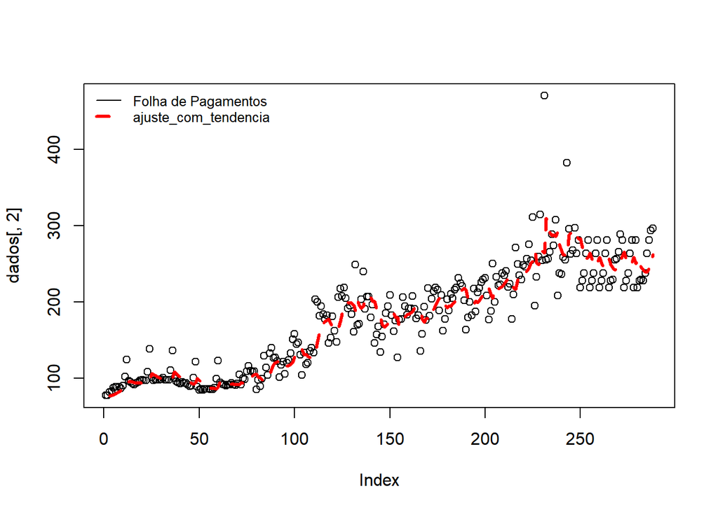

```r
plot(dados[,2])
lines(fitted(ajuste_com_tendenciaFP)[,1],col="red",lty=2,lwd =3)
legend('topleft', legend=c("Folha de Pagamentos", "ajuste_com_tendencia"),bty = "n",
       col=c("black","red"), lty=c(1,2), cex=0.8,lwd =c(1,3))
```

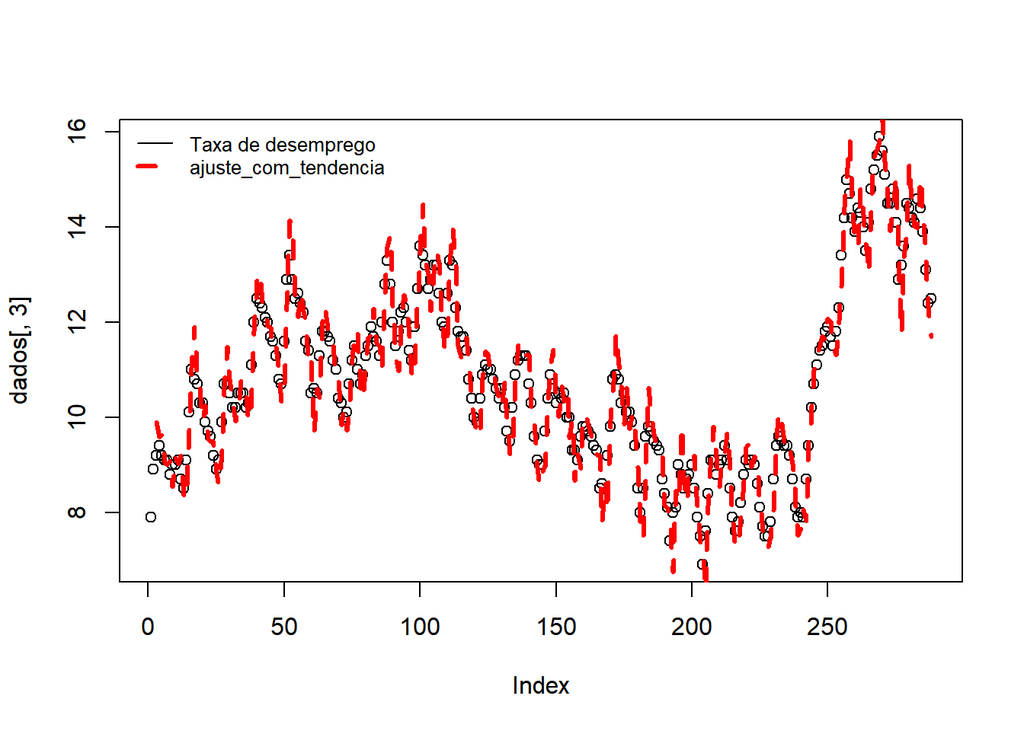

```r
plot(dados[,3])
lines(fitted(ajuste_com_tendenciaTD)[,1],col="red",lty=2,lwd =3)
legend('topleft', legend=c("Taxa de desemprego", "ajuste_com_tendencia"),bty = "n",
       col=c("black","red"), lty=c(1,2), cex=0.8,lwd =c(1,3))
```

O HW ajuda a descobrir padrão de comportamento mais complexos. A previsão desse modelo é feita de acordo com a série que pode ser Sazonal Aditiva ou Sazonal Multiplicativa.

```r
ajuste_com_sazonalidade<-HoltWinters(AirPassengers)
ajuste_com_sazonalidade
```

```
## Holt-Winters exponential smoothing with trend and additive seasonal component.
##
## Call:
## HoltWinters(x = AirPassengers)
##
## Smoothing parameters:
##  alpha: 0.2479595
##  beta : 0.03453373
##  gamma: 1
##
## Coefficients:
##           [,1]
## a   477.827781
## b     3.127627
## s1  -27.457685
## s2  -54.692464
## s3  -20.174608
## s4   12.919120
## s5   18.873607
## s6   75.294426
## s7  152.888368
## s8  134.613464
## s9   33.778349
## s10 -18.379060
## s11 -87.772408
## s12 -45.827781
```

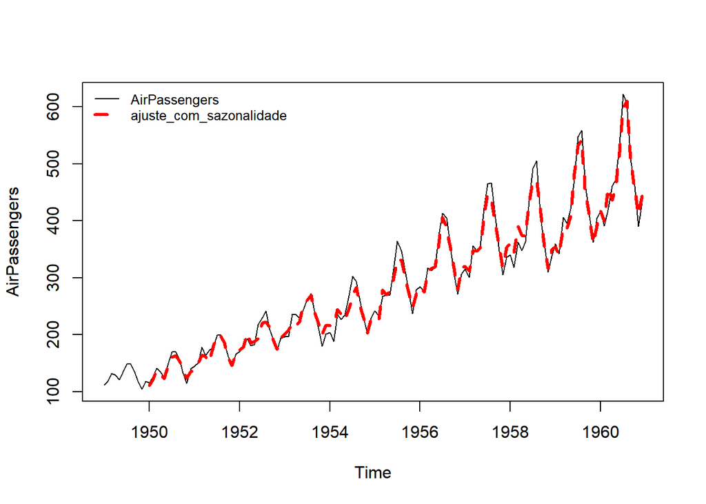

```r
plot(AirPassengers)
lines(fitted(ajuste_com_sazonalidade)[,1],col="red",lty=2,lwd =3)
legend('topleft', legend=c("AirPassengers", "ajuste_com_sazonalidade"),
  bty = "n",col=c("black","red"), lty=c(1,2), cex=0.8,lwd =c(1,3))
```

[output not shown]